# Exploratory Data Analysis

Oct. 31, 2018

## Acknowledgements/References

- Online Text *R for Data Science* by Garrett Grolemund & Hadley Wickham  
  [R for Data Science Ch. 7 - EDA](https://r4ds.had.co.nz/exploratory-data-analysis.html)
- The *Hass Avocado Board* and Justin Kiggins for compiling Avacado data  
  [Dataset csv download link on Kaggle](https://www.kaggle.com/neuromusic/avocado-prices/home)
- Data Visualization published in *Nature Methods*  
  [Nature.com Blog](http://blogs.nature.com/methagora/2013/07/data-visualization-points-of-view.html)
- DataCamp Course by Rick Scavetta: Data Visualization with ggplot

## Intro to Exploratory Data Analysis (EDA)

EDA is a creative process with the purpose of **exploring** your data to generate quality questions. It is not quantitative but more qualitative in nature and is iterative as the exploration inspires questions which become more exploration and so on.

> “There are no routine statistical questions, only questionable statistical routines.” — Sir David Cox

A good starting place for questions:

- What type of variation occurs within my variables?
- What type of covariation occurs between my variables?

To answer these question its crucial to know if our data is Categorical or Numerical.

## The Motivation behind Visual EDA

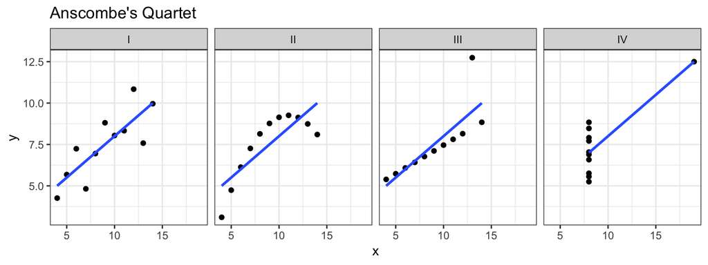

```
## # A tibble: 4 x 6
##   set   `mean(x)` `sd(x)` `mean(y)` `sd(y)` `cor(x, y)`
##   <fct>     <dbl>   <dbl>     <dbl>   <dbl>       <dbl>
## 1 I             9    3.32      7.50    2.03       0.816
## 2 II            9    3.32      7.50    2.03       0.816
## 3 III           9    3.32      7.5     2.03       0.816
## 4 IV            9    3.32      7.50    2.03       0.817
```

## Before Getting Our Hands Dirty

**Finding Data**

- [Google Dataset Tool Search](https://toolbox.google.com/datasetsearch)
- [Kaggle Datasets](https://www.kaggle.com/datasets)
- [Awesome-Public-Dataset Repo](https://github.com/awesomedata/awesome-public-datasets)
- Built in R Datasets or Dataset packages on CRAN. To see the list type `data()` in the console.

## Exploring One Numerical Variable

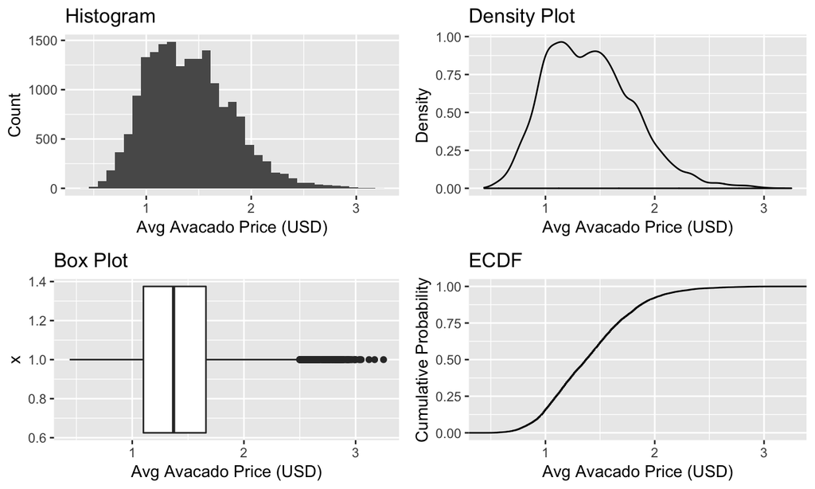

## One Numerical One Categorical

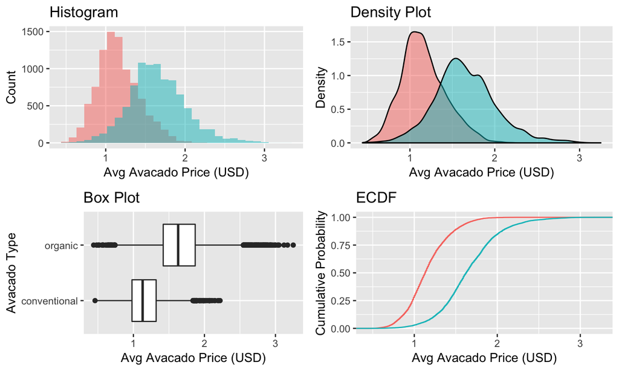

## One Numerical One Categorical (Cont.)

Using `geom_jitter()` and `geom_quasirandom()` with the data set filtered to the region New York.

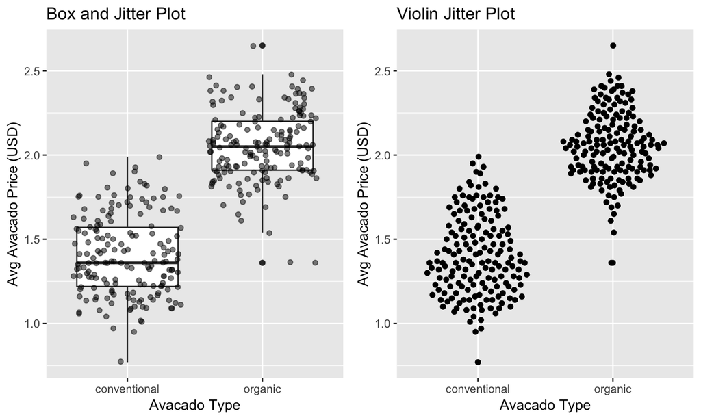

## Two Numerical Variables

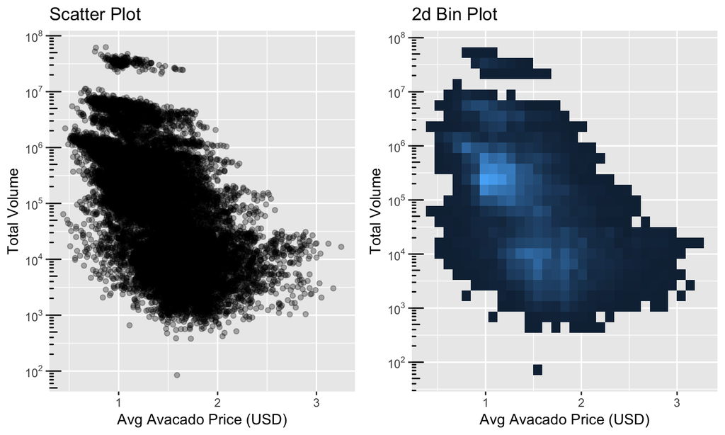

## Exploring More than Two Variables

So far we have been primarily been using position mapping and/or color mapping. But we are able to map more variables to the following aesthetics:

| Aesthetic | Description |
| --- | --- |
| x | X axis position |
| y | Y axis position |
| color | Color of dots, outlines of other shapes |
| fill | Fill color |
| size | Diameter of points, thickness of lines |
| alpha | Transparency |
| linetype | Line dash pattern |
| labels | Text on a plot or axes |
| shape | Shape |

## Categorical Visual Guide

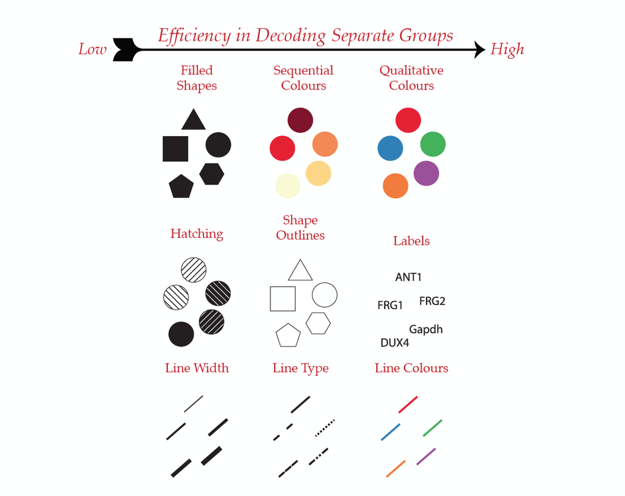

Image adapted by DataCamp from Wong,B, *Nat Met*, 7(9), 2010, p665

## Continous Visual Guide

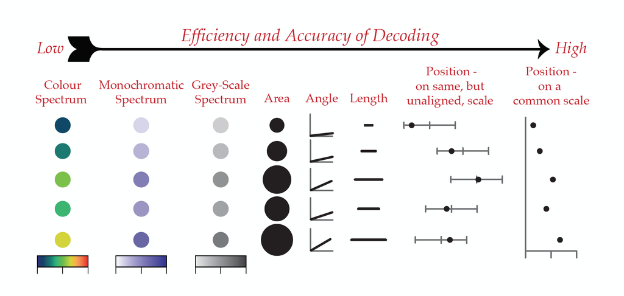

Image adapted by DataCamp from Wong,B, *Nat Met*, 7(9), 2010, p665